# Lecture 04

# Lecture 04: Data Visualization with the `ggplot2` library

# Student Name: Live HTML

# Student ID: NA

## 0.1.0 About Introduction to R

Introduction to R is brought to you by the **Centre for the Analysis of Genome Evolution & Function (CAGEF)** bioinformatics training initiative. This course was developed based on feedback on the needs and interests of the Department of Cell & Systems Biology and the Department of Ecology and Evolutionary Biology.

The structure of this course is a code-along style; It is 100% hands on! A few hours prior to each lecture, links to the materials will be available for download at [QUERCUS](https://q.utoronto.ca/). The teaching materials will consist of an R Markdown Notebook with concepts, comments, instructions, and blank coding spaces that you will fill out with R by coding along with the instructor. Other teaching materials include a live-updating HTML version of the notebook, and datasets to import into R - when required. This learning approach will allow you to spend the time coding and not taking notes!

As we go along, there will be some in-class challenge questions for you to solve either individually or in cooperation with your peers. Post lecture assessments will also be available (see syllabus for grading scheme and percentages of the final mark) through [DataCamp](https://Datacamp.com) to help cement and/or extend what you learn each week.

### 0.1.1 Where is this course headed?

We’ll take a blank slate approach here to R and assume that you pretty much know *nothing* about programming. From the beginning of this course to the end, we want to take you from some potential scenarios such as…

- A pile of data (like an excel file or tab-separated file) full of experimental observations that you don’t know what to do with it.
- Maybe you’re manipulating large tables all in excel, making custom formulas and pivot tables with graphs. Now you have to repeat similar experiments and do the analysis again.
- You’re generating high-throughput data and there aren’t any bioinformaticians around to help you sort it out.
- You heard about R and what it *could* do for your data analysis but don’t know what that means or where to start.

and get you to a point where you can…

- Format your data correctly for analysis.
- Produce basic plots and perform exploratory analysis.
- Make functions and scripts for re-analysing existing or new data sets.
- Track your experiments in a digital notebook like R Markdown!


### 0.1.2 How do we get there? Step-by-step.

In the first lesson, we will talk about the basic data structures and objects in R, get cozy with the R Markdown Notebook environment, and learn how to get help when you are stuck because everyone gets stuck - a lot! Then you will learn how to get your data in and out of R, how to tidy our data (data wrangling), and then subset and merge data. After that, we will dig into the data and learn how to make basic plots for both exploratory data analysis and publication. We’ll follow that up with data cleaning and string manipulation; this is really the battleground of coding - getting your data into just the right format where you can analyse it more easily. We’ll then spend a lecture digging into the functions available for the statistical analysis of your data. Lastly, we will learn about control flow and how to write customized functions, which can really save you time and help scale up your analyses.

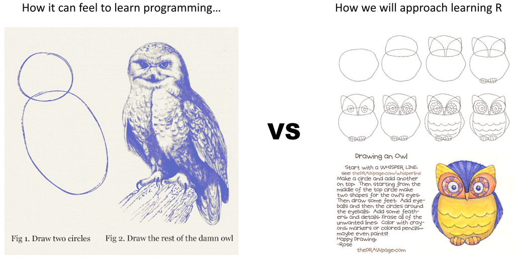

Don’t forget, the structure of the class is a **code-along** style: it is fully hands on. At the end of each lecture, the complete notes will be made available in a PDF format through the corresponding Quercus module so you don’t have to spend your attention on taking notes.

### 0.1.3 What kind of coding style will we learn?

There is no single path correct from A to B - although some paths may be more elegant, or more efficient than others. With that in mind, the emphasis in this lecture series will be on:

1. **Code simplicity** - learn helpful functions that allow you to focus on understanding the basic tenets of good data wrangling (reformatting) to facilitate quick exploratory data analysis and visualization.
2. **Code readability** - format and comment your code for yourself and others so that even those with minimal experience in R will be able to quickly grasp the overall steps in your code.
3. **Code stability** - while the core R code is relatively stable, behaviours of functions can still change with updates. There are well-developed packages we’ll focus on for our analyses. Namely, we’ll become more familiar with the `tidyverse` series of packages. This resource is well-maintained by a large community of developers. While not always the “fastest” approach, this additional layer can help ensure your code still runs (somewhat) smoothly later down the road.

## 0.2.0 Class Objectives

This is the fourth in a series of seven lectures. Last lecture we finished up with basic manipulation of data frames with the help of the `tidyr` package. This week we are taking a break to enjoy the fruits of our labours. Now that we can make properly formatted data frames, we can use these objects as input to produce beautiful, publication-quality data visualizations with the help of the `ggplot2` package. This week our topics are broken into:

1. Introduction to `ggplot` and the grammar of graphics using scatterplots
2. Exploring other types of plots
3. Customizing your plots
4. Saving your plots
5. Taking your plots up a notch by combining them and using additional packages.

[figure not shown]

## 0.3.0 A legend for text format in R Markdown

- `Grey background`: Command-line code, R library and function names. Backticks are also use for in-line code.
- *Italics* or *Bold italics*: Emphasis for important ideas and concepts
- **Bold**: Headers and subheaders
- Blue text: Named or unnamed hyperlinks
- `...` fill in the code here if you are coding along

**Blue box:** A key concept that is being introduced

**Yellow box:** Risk or caution

**Green boxes:** Recommended reads and resources to learn R

**Red boxes:** A comprehension question which may or may not involve a coding cell. You usually find these at the end of a section.

## 0.4.0 Lecture and data files used in this course

### 0.4.1 Weekly Lecture and skeleton files

Each week, new lesson files will appear within your RStudio folders. We are pulling from a GitHub repository using this [Repository git-pull link](https://r.datatools.utoronto.ca/hub/user-redirect/git-pull?repo=https%3A%2F%2Fgithub.com%2Fuoft-csb-datasci%2F2025-09-IntroR&urlpath=rstudio%2F&branch=main). Simply click on the link and it will take you to the [University of Toronto datatools Hub](https://datatools.utoronto.ca). You will need to use your UTORid credentials to complete the login process. From there you will find each week’s lecture files in the directory `/2025-09-IntroR/Lecture_XX`. You will find a partially coded `skeleton.Rmd` file as well as all of the data files necessary to run the week’s lecture.

Alternatively, you can download the R-Markdown Notebook (`.Rmd`) and data files from the RStudio server to your personal computer if you would like to run independently of the Toronto tools.

### 0.4.2 Live-coding HTML page

A live lecture version will be available at [camok.github.io](https://uoft-csb-datasci.github.io/2025-09.IntroToR/index.html) that will update as the lecture progresses. Be sure to refresh to take a look if you get lost!

### 0.4.4 Microsporidia infection data set description

The following datasets used in this week’s class come from a published manuscript on PLoS Pathogens entitled “High-throughput phenotyping of infection by diverse microsporidia species reveals a wild *C. elegans* strain with opposing resistance and susceptibility traits” by [Mok et al., 2023](https://journals.plos.org/plospathogens/article?id=10.1371/journal.ppat.1011225). These datasets focus on the an analysis of infection in wild isolate strains of the nematode *C. elegans* by environmental pathogens known as microsporidia. The authors collected embryo counts from individual animals in the population after population-wide infection by microsporidia and we’ll spend our next few classes working with the dataset to learn how to format and manipulate it.

### 0.4.4.1 Dataset 1: data/infection_signal.tsv

This is an imaging analysis of infected *C. elegans* strains N2 and JU1400 measuring the overall number of pixels for each animals and the number of fluorescent (infected) pixels within the same area.

### 0.4.4.2 Dataset 2: data/embryo_data_long_merged.csv

This is a result of our efforts (mostly) from last lecture. After transforming a wide-format version of our measurement data, we merged it with some metadata regarding our experiments and now it is ready to be visualized!

### 0.4.4.3 Dataset 3: data/infection_meta.csv

We’ll return to this metadata towards the end of lecture but it holds all of the experimental condition information that has been integrated into the `embryo_data_long_merged.csv` file.

## 0.5.0 Packages used in this lesson

The following packages are used in this lesson:

- `tidyverse` (tidyverse installs several packages for you, like `dplyr`, `readr`, `readxl`, `tibble`, and `ggplot2`)
- `RColorBrewer` contains a series of different colour palettes
- `viridis` contains alternative colour-blind friendly colour palettes
- `ggbeeswarm` a package to help visualized grouped datapoints in a sensible way
- `ggthemes` a source for alternative plot themes
- `ggpubr` used to generate multi-plot figures for publication
- `gridExtra` works with ggpubr to produce multi-plot figures
- `ComplexUpset` an alternative visualization package to classic Venn diagrams
- `ggrepel` used to avoid text overlap (See Appendix)

This week we’ll have a few steps to accomplish installing/working with one of our packages so please follow the instructions carefully.

```r
# Step 1: remove ggplot and reinstall it IF your first attempt to install has failed
remove.packages("ggplot2")
remove.packages("ComplexUpset")

# This last line will restart the kernel for you.
.rs.restartR()
```

If your kernel did not already do so, **restart your kernel** via the menu at **`Session > Restart R`** or using `Ctrl + Shift + F10`.

```r
# Step 2: after restarting the kernel...
library(remotes)
# Say no to updating any additional packages while installing ggplot2 and ComplexUpset
install_version("ggplot2", version = "3.5.2", repos = 'http://cran.us.r-project.org')
```

[output not shown]

```
## Skipping 1 packages not available: scales
```

```
## Installing 6 packages: rlang, glue, cli, vctrs, magrittr, tibble
```

```r
install.packages("ComplexUpset", type = "source")
```

Proceed with installing the remainder of the packages.

```r
#--------- Step 3: Install remaining packages to for today's session ----------#
# None of these packages are already available on JupyterHub
install.packages("ggbeeswarm", dependencies = TRUE)
install.packages("ggthemes", dependencies = TRUE)
install.packages("ggpubr", dependencies = TRUE)
```

### 0.5.1 You must restart the kernel after initially installing the above packages

```r
#--------- RESTART THE KERNEL BEFORE LOADING PACKAGES! ----------#
#--------- Load packages to for today's session ----------#
library(tidyverse)
library(ggbeeswarm)
library(RColorBrewer)
library(viridis)
library(ggthemes)
library(ggpubr)
library(ComplexUpset)
```

# 1.0.0 Introduction to the Grammar of Graphics

One approach to effective data visualization relies on the Grammar of Graphics framework originally proposed by Leland Wilkinson (2005).The idea of grammar can be summarized as follows:

- Grammar is the foundational set of rules that define the components of a language.
- A language is built on a structure that consists of syntax and semantics.

The **grammar of graphics** is a language to define plotting in a programmatic fashion.

- It begins with a **tidy** data frame. It will have a series of **observations** (rows) each of which will be described across multiple **variables** (columns). Variables can actually represent qualitative or quantitative measurements or they could be descriptive data about the experiments or experimental groups.
- The data units may undergo conversion through a process called **scaling** (transformation) before being used for plotting.
- A subset of data columns are then passed on to be presented in various data plots (scatterplots, boxplots, kernel density estimates, etc.) by using the data to describe visual properties of the plot. We call these visual properties, the **aesthetics** of the plot. For example, the data being plotted or represented can be visually altered in shape or colour based on accompanying column data.
- A plot can have multiple layers (for example, a scatter plot with a regression line) and each of these plot types is referred to as a **geom** (short for *geometric object*).

## 1.1.0 The grammar of graphics with `ggplot2`

The grammar of graphics facilitates the concise description of any components of any graphics. Hadley Wickham of `tidyverse` fame has proposed a variant on this concept - the layered grammar of graphics framework. By following a layered approach of defined components, it can be easy to build a visualization. `ggplot2` was made to interact well with tidy (long) datasets. If, however, you are spending lots of time figuring out how to make a scatterplot, your data may not be in the correct format.

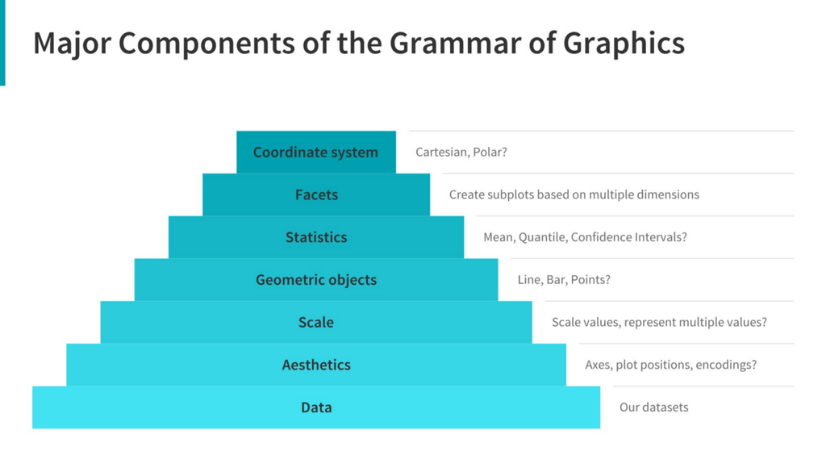

The Major Components of the Grammar of Graphics by [Dipanjan Sarkar](https://towardsdatascience.com/a-comprehensive-guide-to-the-grammar-of-graphics-for-effective-visualization-of-multi-dimensional-1f92b4ed4149)

We can break down the above pyramid by the base components, building from the base upwards.

1. `Data`: your visualization always starts here. What are the dimensions you want to visualize. What aspect of your data are you trying to convey?
2. `Aesthetics`: assign your axes based on the data dimensions you have chosen. Where will the majority of the data fall on your plot? Are there other dimensions (such as categorically encoded groupings) that can be conveyed by aspects like size, shape, colour, fill, etc. This is also known as the *mapping layer* as we define how variables are *mapped* to various kinds of output.
3. `Scale`: do you need to scale/transform any values to fit your data within a range? This includes layers that map between the data and the aesthetics.
4. `Geometric objects`: how will you display your data within your visualization. Which `geom_*` will you use?
5. `Statistics`: are there additional summary statistics that should be included in the visualization? Some examples include central tendency, spread, confidence intervals, standard error, etc.
6. `Facets`: will generating subplot of the data add a dimension to our visualization that would otherwise be lost?
7. `Coordinate system`: will your visualization follow a classic cartesian, semi-log, polar, etc. coordinate system?

Let’s jump into our first dataset and start building some plots with it shall we?

## 1.2.0 Build a `ggplot` layer by layer

Let’s build our first plot step by step to learn more about how `ggplot2` works. We will begin by loading datasets from some fluorescence microscopy analysis of *C. elegans* animals infected by the microsporidia *N. ferruginous*. This long-format data was measured for total area per animal as well as infected area (ie fluorescent signal) per animal.

Let’s read our first data table. We already loaded the `tidyverse` package in **section 0.5.0** along with a handful of additional packages. You may recall from the startup message that `ggplot2` was one of the attached packages.

```r
# Open up the microscopy analysis data
infection_sig.df <- read_tsv("data/infection_signal.tsv")
# Take a look at the data structure
str(infection_sig.df, give.attr = FALSE)
```

```
## spc_tbl_ [456 x 14] (S3: spec_tbl_df/tbl_df/tbl/data.frame)
##  $ exp.name        : chr [1:456] "N2-LUAm1-1.8" "N2-LUAm1-1.8" "N2-LUAm1-1.8" "N2-LUAm1-1.8" ...
##  $ strain          : chr [1:456] "N2" "N2" "N2" "N2" ...
##  $ spore.strain    : chr [1:456] "LUAm1" "LUAm1" "LUAm1" "LUAm1" ...
##  $ spore.species   : chr [1:456] "N.ferruginous" "N.ferruginous" "N.ferruginous" "N.ferruginous" ...
##  $ dose            : chr [1:456] "pulse-72H" "pulse-72H" "pulse-72H" "pulse-72H" ...
##  $ spores          : num [1:456] 1.8 1.8 1.8 1.8 1.8 1.8 1.8 1.8 1.8 1.8 ...
##  $ fixing.date     : chr [1:456] "rep1" "rep1" "rep1" "rep1" ...
##  $ slide           : num [1:456] 1 1 1 1 1 1 1 1 1 1 ...
##  $ file            : chr [1:456] "N2.LUAm1.rep1" "N2.LUAm1.rep1" "N2.LUAm1.rep1" "N2.LUAm1.rep1" ...
##  $ worm.number     : num [1:456] 1 2 3 4 5 6 7 8 9 10 ...
##  $ area            : num [1:456] 49838 50425 45533 46459 49215 ...
##  $ percent.infected: num [1:456] 18.53 0 31.16 3.88 0 ...
##  $ area.infected   : num [1:456] 9235 0 14188 1803 0 ...
##  $ timepoint       : chr [1:456] "72hpi" "72hpi" "72hpi" "72hpi" ...
```